# Notebook

**Authors** Pratyush Tiwary, Shams Mehdi, Dedi Wang

**Date** May 16, 2022

**Aims**

This masterclass is a continuation (part 2) of the previously introduced [ State Predictive Information Bottleneck (SPIB)](https://aip.scitation.org/doi/10.1063/5.0038198. We will show you how to train an SPIB model from data obtained from Molecular Dynamics and perform Metadynamics by biasing the SPIB learnt reaction coordinates.

**Prerequisites**

**Please change colab runtime to GPU Hardware accelerator.**

You should have a working knowledge of Python. Some familiarity with PyTorch is useful but not essential.

**Objectives**

1. Use SPIB to analyze alanine dipeptide trajectory (in vacuum)
2. Use SPIB to perform biased metadynamics simulations

**Step 0.a**:  
Install conda and activate a conda environment. You will be prompted to manually type in y (for yes).

```python
# INSTALL CONDA ON GOOGLE COLAB
! wget https://repo.anaconda.com/miniconda/Miniconda3-latest-Linux-x86_64.sh
! chmod +x Miniconda3-latest-Linux-x86_64.sh
! bash ./Miniconda3-latest-Linux-x86_64.sh -b -f -p /usr/local
import sys
import os
# Update path for the new conda's Python
python_ver = f"python{sys.version_info.major}.{sys.version_info.minor}"
sys.path.append(f'/usr/local/lib/{python_ver}/site-packages/')
!conda tos accept --override-channels --channel https://repo.anaconda.com/pkgs/main
!conda tos accept --override-channels --channel https://repo.anaconda.com/pkgs/r

# Create conda environemt
!conda create --name plumed-masterclass-2022 -y python=3.7
```

[output not shown]

[output cut: 187 more lines]

```




Preparing transaction: / - done
Verifying transaction: | / - \ | / - \ | / done
Executing transaction: \ | / - \ done
#
# To activate this environment, use
#
#     $ conda activate plumed-masterclass-2022
#
# To deactivate an active environment, use
#
#     $ conda deactivate
```

**Step 0.b**:  
Install plumed, and a specific verion of Gromacs (2018.6) pre-patched with plumed, and other libraries (takes about 5-10 minutes)

```python
# Activate conda environment
%%bash
source activate plumed-masterclass-2022
echo $CONDA_DEFAULT_ENV

conda install -c anaconda numpy -y
conda install -c conda-forge matplotlib -y
conda install -c pytorch pytorch=1.11 -y
conda install -c plumed/label/lugano -c conda-forge plumed -y
conda install -c plumed/label/lugano -c conda-forge gromacs=2018.6 -y
```

[output not shown]

[output cut: 3170 more lines]

```











                                                      done
Preparing transaction: | done
Verifying transaction: - \ | / done
Executing transaction: \ | done
```

[output not shown]

**Step 0.c**:  
Load necessary python libraries and matplotlib graph visualization parameters.

```python
import numpy as np
import matplotlib.pyplot as plt
import time
import torch
from torch import nn
import importlib.util
import sys
import pandas as pd

sys.path.append('SPIB_scripts/')
np.random.seed(42)

large = 24; med = 12; small = 8
l_width = 3; m_width = 1.5; s_width = 0.7
params = {'axes.titlesize': large,
          'legend.fontsize': large,
          'legend.title_fontsize':large,
          'figure.figsize': (16, 10),
          'axes.labelsize': large,
          'xtick.labelsize': med,
          'ytick.labelsize': med,
          'figure.titlesize': large,
          'lines.linewidth': l_width,
          'lines.markersize': 2,
          'axes.linewidth': l_width,
          'xtick.major.size': 8,
          'ytick.major.size': 8,
          'xtick.minor.size': 4,
          'ytick.minor.size': 4,
          'xtick.major.width': m_width,
          'ytick.major.width': m_width,
          'xtick.minor.width': s_width,
          'ytick.minor.width': s_width,
          'grid.linewidth': m_width}
plt.rcParams.update(params)
```

```python
!npx degit shams-mehdi/SPIB-plumed-masterclass-2022 -f
```

```
⠙⠹⠸⠼⠴⠦⠧⠇⠏⠋⠙⠹⠸⠼⠴Need to install the following packages:
degit@2.8.4
Ok to proceed? (y) y

⠙⠹⠸> destination directory is not empty. Using --force, continuing
> cloned shams-mehdi/SPIB-plumed-masterclass-2022#HEAD
⠙
```

**Step 2**:  
Load the unbiased trajectory -> visualize (φ, ψ) time series for the first 100.0 ps -> create a free energy plot for the entire trajectory.

```
Number of saved frames:  2000000 , Number of features:  4
```

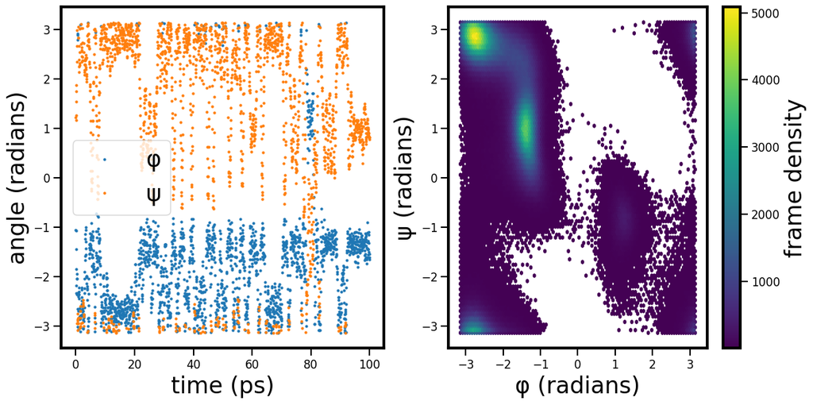

```python
traj_raw = np.load("aladip_inputs/aladip_unbiased_trajectory.npy")
print('Number of saved frames: ', traj_raw.shape[0], ', Number of features: ', traj_raw.shape[1])

## Loaded numpy arrays contain datapoints saved every 0.05ps. The first 2000 steps (100.00 ps) are selected for time series visualization
data_resolution = 0.05
datapoints_tseries = 2000
time = np.arange(datapoints_tseries)*data_resolution

fig, ax = plt.subplots(1, 2, figsize = (12,6))
## Time Series plot
ax[0].plot(time, traj_raw[:datapoints_tseries,0], 'o', label = 'φ')
ax[0].plot(time, traj_raw[:datapoints_tseries,1], 'o', label = 'ψ')
ax[0].set_xlabel('time (ps)')
ax[0].set_ylabel('angle (radians)')
ax[0].legend()

## FES plot of entire trajectory
fes = ax[1].hexbin(traj_raw[:,0], traj_raw[:,1], mincnt=1)
ax[1].set_xlabel('φ (radians)')
ax[1].set_ylabel('ψ (radians)')
cb = fig.colorbar(fes, ax=ax[1])
cb.set_label('frame density')
fig.tight_layout()
```

**Step 3**:  
Assign initial states by binning data along φ dihedral angle. Create 8 OP SPIB input data (sin-cos of φ, ψ, θ, ω) from (φ, ψ, θ, ω) trajectory.

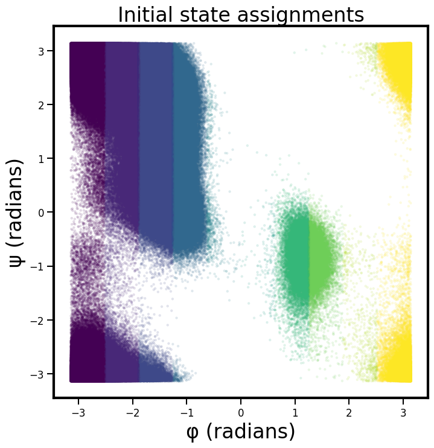

```python
#@title One-hot encoded initial state assignment
num_labels = 10 #@param {type:"integer"}
# 10 initial states assigned to the trajectory by binning along φ

# Creating one hot vectors for initial states
bins = np.linspace(start = -np.pi, stop = np.pi, num = num_labels, endpoint = False)
binned_data = np.digitize(traj_raw[:,0], bins)-1
one_hot_labels = np.zeros((traj_raw.shape[0], num_labels))
one_hot_labels[np.arange(traj_raw.shape[0]),binned_data] = 1

# Save one-hot encoded initial states
np.save("aladip_inputs/labels.npy", one_hot_labels)

# Visualize initial states
fig, ax = plt.subplots(figsize = (8,8))
ax.scatter(traj_raw[:, 0], traj_raw[:, 1], c=binned_data, s=5, alpha=.1)
ax.set_title('Initial state assignments')
ax.set_xlabel('φ (radians)')
ax.set_ylabel('ψ (radians)')

# Create and save 8 OP SPIB input
traj_sincos = np.zeros((traj_raw.shape[0], 2*traj_raw.shape[1]))
for i in range(traj_raw.shape[1]):
  traj_sincos[:, 2*i] = np.sin(traj_raw[:, i])
  traj_sincos[:, 2*i + 1] = np.cos(traj_raw[:, i])

np.save('aladip_inputs/trajectory_sincos.npy', traj_sincos)
```

**Step 4**:  
Train a nonlinear SPIB (ver July, 2021) model by choosing appropriate hyperparmeters.

Time delay = dt*0.05 ps, heuristic for batch size = 0.1% of trajectory length

```python
#@title Select SPIB hyperparameters
## Train an SPIB model with time delay = 0.25 ps

dt = 5 #@param {type:"integer"}
rc_dim = 2 #@param {type:"integer"}
encoder_type = 'Nonlinear' #@param {type:"string"}
neuron_num1 = 16 #@param {type:"integer"}
neuron_num2 = 16 #@param {type:"integer"}
## heuristic for batch size is to set it ~ 0.1% of the trajectory length
batch_size = 2048 #@param {type:"integer"}
refinements = 15 #@param {type:"integer"}
learning_rate = 0.0001 #@param {type:"number"}
beta = 0.001 #@param {type:"number"}
seed = 0 #@param {type:"integer"}
traj_path = 'aladip_inputs/trajectory_sincos.npy'
initial_states_path = 'aladip_inputs/labels.npy'
SPIB_OPs = traj_sincos.shape[1]
Weighted_or_not = "Unweighted"
```

```python
# Train SPIB model
!bash -c "source activate plumed-masterclass-2022 && python SPIB_scripts/test_model.py -dt {dt} -d {rc_dim} -encoder_type {encoder_type} -bs {batch_size} -n1 {neuron_num1} -n2 {neuron_num2} -refinements {refinements} -lr {learning_rate} -b {beta} -seed {seed} -label {initial_states_path} -traj {traj_path}"
```

```
Iteration 500:	Time 3.473728 s
Loss (train) 1.956074	KL loss (train): 0.415344
Reconstruction loss (train) 1.955659
Loss (test) 1.951517	KL loss (test): 0.430974
Reconstruction loss (test) 1.951086
tensor([0., 0., 1., 0., 0., 0., 0., 0., 0., 0.])
State population change=0.754875
Epoch: 1

Iteration 1000:	Time 7.282437 s
Loss (train) 1.467773	KL loss (train): 1.152972
Reconstruction loss (train) 1.466620
Loss (test) 1.486780	KL loss (test): 1.160592
Reconstruction loss (test) 1.485620
Iteration 1500:	Time 10.175458 s
Loss (train) 1.418230	KL loss (train): 1.734267
Reconstruction loss (train) 1.416495
Loss (test) 1.401511	KL loss (test): 1.637989
Reconstruction loss (test) 1.399873
tensor([5.4164e-01, 0.0000e+00, 4.3774e-01, 1.1056e-04, 0.0000e+00, 0.0000e+00,
        2.0515e-02, 0.0000e+00, 0.0000e+00, 0.0000e+00])
State population change=0.780980
Epoch: 2

Iteration 2000:	Time 14.365273 s
Loss (train) 1.094166	KL loss (train): 4.426075
Reconstruction loss (train) 1.089740
Loss (test) 1.098745	KL loss (test): 4.308545
Reconstruction loss (test) 1.094436
Iteration 2500:	Time 16.830657 s
Loss (train) 0.975056	KL loss (train): 4.009392
Reconstruction loss (train) 0.971046
Loss (test) 0.990216	KL loss (test): 4.189766
Reconstruction loss (test) 0.986026
tensor([5.0047e-01, 0.0000e+00, 4.7888e-01, 0.0000e+00, 0.0000e+00, 0.0000e+00,
        2.0636e-02, 1.1111e-05, 0.0000e+00, 0.0000e+00])
State population change=0.058205
Epoch: 3

Iteration 3000:	Time 20.381057 s
```

[output cut: 334 more lines]

```
Iteration 22500:	Time 177.000175 s
Loss (train) 0.183221	KL loss (train): 4.602883
Reconstruction loss (train) 0.178619
Loss (test) 0.217848	KL loss (test): 4.737558
Reconstruction loss (test) 0.213111
tensor([0.6010, 0.0000, 0.3784, 0.0000, 0.0000, 0.0000, 0.0206, 0.0000, 0.0000,
        0.0000])
State population change=0.001283
Total training time: 180.509318
Final: 0
Loss (train) 0.183330	KL loss (train): 4.539133
Reconstruction loss (train) 0.178791
Loss (test) 0.185203	KL loss (train): 4.555464
Reconstruction loss (test) 0.180648
dt: 5	 Beta: 0.001000	 Learning_rate: 0.000100
```

**Step 5**:  
Visualize converged SPIB states

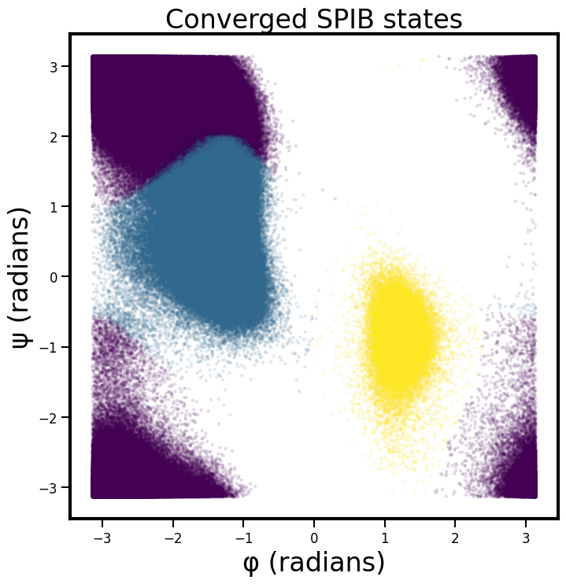

```python
## Number of trajectories in this analysis
num_traj = 1
## Construct file path from chosen hyperparameter values
path = "SPIB/" + Weighted_or_not + "_d=" + str(rc_dim) + "_t=" + str(dt) + "_b=" + "{:.4f}".format(beta) + "_learn=" + "{:.6f}".format(learning_rate)

one_hot_converged_labels = np.load(path + "_traj" + str(num_traj-1) + "_labels" + str(seed) + ".npy")
converged_labels = np.zeros((one_hot_converged_labels.shape[0]), dtype = 'int')

for i in range(converged_labels.shape[0]):
  converged_labels[i] = np.nonzero(one_hot_converged_labels[i,:])[0]

fig, ax = plt.subplots(figsize = (8,8))
ax.scatter(traj_raw[:, 0], traj_raw[:, 1], c=converged_labels, s=5, alpha=.1)
ax.set_title('Converged SPIB states')
ax.set_xlabel('φ (radians)')
ax.set_ylabel('ψ (radians)')
```

**Step 6**: Create plumed input from saved SPIB model

```python
# Note: When encountering following error: "module SPIB has no attribute SPIB", restart runtime and run all except SPIB training cell.
#@title Metadynamics parameters
sigma_mul = 0.2 #@param {type:"number"}
grid_mul = 5 #@param {type:"number"}
height = 1.5 #@param {type:"number"}
bias_factor = 10 #@param {type:"number"}
pace = 2000 #@param {type:"integer"}
stride = 100 #@param {type:"integer"}
grid_bins = 500 #@param {type:"integer"}
file_name = "plumed_SPIB_aladip.dat" #@param {type:"string"}

import torch
from torch import nn
import SPIB


device = torch.device("cuda:0" if torch.cuda.is_available() else "cpu")
path = "SPIB/" + Weighted_or_not + "_d=" + str(rc_dim) + "_t=" + str(dt) + "_b=" + "{:.4f}".format(beta) + "_learn=" + "{:.6f}".format(learning_rate)

data_shape=SPIB_OPs
# Update Label should be set to False for testing purposes only
UpdateLabel = True
# Load patameters from SPIB checkpoint
restore_path= path + 'cpt0/IB_final_cpt.pt'
representative_inputs_path=path + '_representative_inputs' + str(seed) + '.npy'
representative_inputs = torch.tensor(np.load(representative_inputs_path))
IB = SPIB.SPIB(encoder_type, rc_dim, num_labels, data_shape, device, UpdateLabel, neuron_num1, neuron_num2)
IB.reset_representative(representative_inputs)
checkpoint=torch.load(restore_path)
IB.load_state_dict(checkpoint['state_dict'])

weight0=IB.encoder[0].weight.cpu().data.numpy()
weight1=IB.encoder[2].weight.cpu().data.numpy()
weight2=IB.encoder_mean.weight.cpu().data.numpy()
bias0=IB.encoder[0].bias.cpu().data.numpy()
bias1=IB.encoder[2].bias.cpu().data.numpy()
bias2=IB.encoder_mean.bias.cpu().data.numpy()

with open('aladip_inputs/header.txt', 'r') as f:
  head = f.read()
header = head + "\n"

## Calculate standard deviation of the RC and mutiply by sigma_mul to obtain sigma for metadynamics
traj_rc = np.load(path + "_traj" + str(num_traj-1) + "_mean_representation" + str(seed) + ".npy")
rc1_sigma = np.std(traj_rc[:,0])*sigma_mul
rc2_sigma = np.std(traj_rc[:,1])*sigma_mul

## Set grid_min and grid_max
rc1_grid_min = np.min(traj_rc[:,0]) - grid_mul*rc1_sigma
rc2_grid_min = np.min(traj_rc[:,1]) - grid_mul*rc2_sigma

rc1_grid_max = np.max(traj_rc[:,0]) + grid_mul*rc1_sigma
rc2_grid_max = np.max(traj_rc[:,1]) + grid_mul*rc2_sigma

dihedrals = ['phi', 'psi', 'theta', 'omega']
with open(file_name, 'w') as f:
    f.writelines(header)
    f.write('\n')

    input_OPs = ''
    for i in dihedrals:
      input_OPs += "sin_" + i + ",cos_" + i +","
    # 1st layer
    for i in range(weight0.shape[0]):
        toprint = f"l1_{i+1}: COMBINE ARG=" + input_OPs
        toprint = toprint[:-1] + " COEFFICIENTS="
        for j in range(weight0.shape[1]):
            toprint = toprint + "%0.12f," % (weight0[i,j])
        toprint = toprint[:-1] + " PERIODIC=NO\n"
        f.write(toprint)
    for i in range(weight0.shape[0]):
        onebias = bias0[i]
        # Relu as activation function
        if onebias >= 0:
            printfun = "step(x+%0.12f)*(x+%0.12f)" % (onebias,onebias)
        else:
            printfun = "step(x-%0.12f)*(x-%0.12f)" % (-onebias,-onebias)
        f.write("l1r_%i: MATHEVAL ARG=l1_%i FUNC=%s PERIODIC=NO\n" % (i+1,i+1,printfun))

    # 2nd layer
    for i in range(weight1.shape[0]):
        toprint = "l2_%i: COMBINE ARG=" % (i+1)
        for j in range(weight0.shape[0]):
          toprint = toprint + "l1r_%i," % (j+1)
        toprint = toprint[:-1] + " COEFFICIENTS="
        for j in range(weight0.shape[0]):
          toprint = toprint + "%0.12f," % (weight1[i,j])
        toprint = toprint[:-1] + " PERIODIC=NO\n"
        f.write(toprint)
    for i in range(weight1.shape[0]):
        onebias = bias1[i]
        # Relu as activation function
        if onebias >= 0:
            printfun = "step(x+%0.12f)*(x+%0.12f)" % (onebias,onebias)
        else:
            printfun = "step(x-%0.12f)*(x-%0.12f)" % (-onebias,-onebias)
        f.write("l2r_%i: MATHEVAL ARG=l2_%i FUNC=%s PERIODIC=NO\n" % (i+1,i+1,printfun))

    # 3rd layer/Linear Output
    for i in range(weight2.shape[0]):
        toprint = "l3_%i: COMBINE ARG=" % (i+1)
        for j in range(weight1.shape[0]):
          toprint = toprint + "l2r_%i," % (j+1)
        toprint = toprint[:-1] + " COEFFICIENTS="
        for j in range(weight1.shape[0]):
          toprint = toprint + "%0.12f," % (weight2[i,j])
        toprint = toprint[:-1] + " PERIODIC=NO\n"
        f.write(toprint)

    output_variable=''
    for i in range(weight2.shape[0]):
        output_variable=output_variable+"l3_%i," % (i+1)
    output_variable=output_variable[:-1]

    f.write(f'\nMETAD ...\nLABEL=metad\nARG='+output_variable+f' SIGMA={rc1_sigma},{rc2_sigma} HEIGHT={height} BIASFACTOR={bias_factor} TEMP=450.0 PACE={pace}\nGRID_MIN={rc1_grid_min},{rc2_grid_min} GRID_MAX={rc1_grid_max},{rc2_grid_max} \nCALC_RCT\n... METAD\n')
    f.write('\n')

    f.write('\nPRINT ARG='+input_OPs+output_variable+',metad.bias,metad.rbias'+f' STRIDE={stride} FILE=COLVAR')
```

**Step 7:**  
Perform 2.5 ns SPIB augmented metadynamics

```python
!bash -c "source activate plumed-masterclass-2022 && gmx grompp -f aladip_inputs/aladip.mdp -o aladip_inputs/aladip.tpr -c aladip_inputs/aladip.gro -p aladip_inputs/aladip.top -maxwarn -1"
```

[output not shown]

[output cut: 45 more lines]

```
Calculating fourier grid dimensions for X Y Z
Using a fourier grid of 24x24x24, spacing 0.104 0.104 0.104
Estimate for the relative computational load of the PME mesh part: 0.95

NOTE 6 [file aladip_inputs/aladip.mdp]:
  The optimal PME mesh load for parallel simulations is below 0.5
  and for highly parallel simulations between 0.25 and 0.33,
  for higher performance, increase the cut-off and the PME grid spacing.


This run will generate roughly 11 Mb of data

There were 6 notes

GROMACS reminds you: "A curious aspect of the theory of evolution is that everybody thinks he understands it." (Jacques Monod)
```

```python
!bash -c "source activate plumed-masterclass-2022 && gmx mdrun -v -deffnm aladip_inputs/aladip --plumed plumed_SPIB_aladip.dat -ntomp 1"
```

[output not shown]

[output cut: 8 more lines]

```

NOTE: Thread affinity was not set.
starting mdrun 'Gromacs Runs One Microsecond At Cannonball Speeds'
1250000 steps,   2500.0 ps.
step 1249900, remaining wall clock time:     0 s
Writing final coordinates.

Back Off! I just backed up aladip_inputs/aladip.gro to aladip_inputs/#aladip.gro.1#
step 1250000, remaining wall clock time:     0 s
               Core t (s)   Wall t (s)        (%)
       Time:      549.628      549.628      100.0
                 (ns/day)    (hour/ns)
Performance:      392.993        0.061

GROMACS reminds you: "In ancient times they had no statistics so they had to fall back on lies." (Stephen Leacock)
```

```python
!head COLVAR
```

```
#! FIELDS time sin_phi cos_phi sin_psi cos_psi sin_theta cos_theta sin_omega cos_omega l3_1 l3_2 metad.bias metad.rbias
 0.000000 -0.867184 0.497987 0.000000 1.000000 0.008598 0.999963 -0.000000 -1.000000 3.384946 -4.738668 0.000000 0.000000
 0.200000 -0.092865 -0.995679 -0.096682 0.995315 0.619568 0.784943 0.089769 -0.995963 3.296247 -2.960988 0.000000 0.000000
 0.400000 -0.329210 -0.944257 -0.897902 0.440195 -0.566463 0.824087 -0.091126 -0.995839 4.600977 -1.807762 0.000000 0.000000
 0.600000 -0.791422 -0.611270 0.430523 -0.902580 -0.322593 0.946538 0.179363 -0.983783 6.430232 -1.576339 0.000000 0.000000
 0.800000 -0.986941 0.161084 0.826780 0.562526 0.064945 0.997889 -0.105369 -0.994433 3.632548 -4.437954 0.000000 0.000000
 1.000000 -0.977058 0.212974 -0.562062 0.827095 0.561884 0.827216 -0.073946 -0.997262 3.271484 -4.434225 0.000000 0.000000
 1.200000 -0.750465 -0.660910 -0.414182 0.910194 -0.330324 0.943867 0.015386 -0.999882 3.500283 -3.682338 0.000000 0.000000
 1.400000 0.085674 -0.996323 -0.736211 0.676752 0.116935 0.993140 -0.473212 -0.880949 3.417346 -1.699877 0.000000 0.000000
 1.600000 -0.799637 -0.600484 -0.998510 0.054568 -0.295290 0.955408 0.236495 -0.971633 4.767683 -2.248133 0.000000 0.000000
```

**Step 8:**  
Convert metadynamics output into a numpy array and visualize SPIB augmented metadynamics result

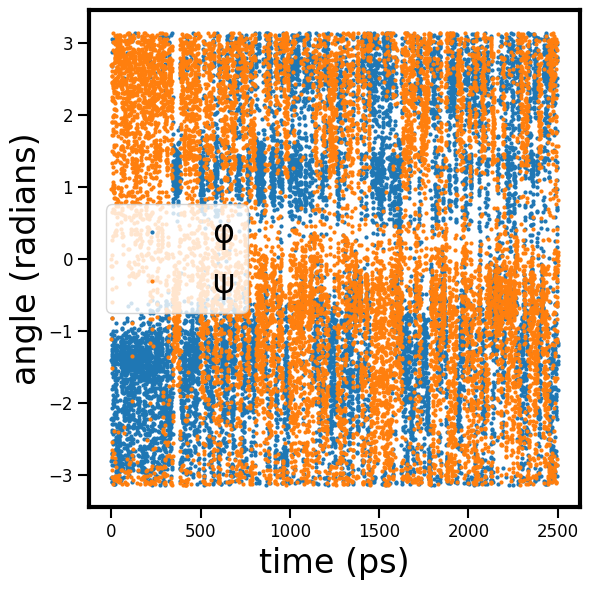

```python
metad_traj = np.loadtxt("COLVAR")
## 8 OP SPIB-metadynamics COLVAR is converted into 4 OP numpy array
metad_dihedrals = np.zeros((metad_traj.shape[0], 4))
for i in range(4):
  metad_dihedrals[:,i] = np.arctan2(metad_traj[:, 1 + 2*i], metad_traj[:, 2*i + 2])

metad_data_resolution = stride * 0.002
metad_time = np.arange(metad_dihedrals.shape[0])*metad_data_resolution

fig, ax = plt.subplots(figsize = (6,6))
## Time Series plot
ax.plot(metad_time, metad_dihedrals[:,0], 'o', label = 'φ')
ax.plot(metad_time, metad_dihedrals[:,1], 'o', label = 'ψ')
ax.set_xlabel('time (ps)')
ax.set_ylabel('angle (radians)')
ax.legend()
fig.tight_layout()
```

**Exercise:**  
(a) Instead of using sines/cosines, directly use the dihedral angles to train SPIB and bias accordingly.  
(b) Change/increase number of neurons in encoder/decoder and check/plot performance.  
(c) Input files for two other systems ([recently published article](https://pubs.acs.org/doi/abs/10.1021/acs.jctc.2c00058)) for studying chiral transitions of a peptide and permeation of a small molecule through a lipid membrane are available in [PLUMED-NEST](https://www.plumed-nest.org/eggs/22/011/).

**Note**: Advanced users may improve SPIB augmented metadynamics performance by upto 30%, by employing libtorch implementation of plumed. If interested please feel free to get in touch and we would be happy to help.